# Tbx5 analysis

## Tbx5 transcription factor analysis

### Introduction

This part of the work provides the analysis that was performed using the data from seven ChIP-seq experiments which analyzed Tbx5 transcription factor abundance in *Mus musculus* organism.

The experiments that were used for *Mus musculus* Tbx5 transcription factor analysis are listed below.

*Mus musculus:*

- [1. EXP058852](https://gtrd.biouml.org/#!table/gtrd_current.experiments/%20Details/ID=EXP058852) (*heart ventricle*)
- [2. EXP030898](https://gtrd.biouml.org/#!table/gtrd_current.experiments/%20Details/ID=EXP030898) (*HL-1 (cardiac muscle cells)*)
- [3. EXP062056](https://gtrd.biouml.org/#!table/gtrd_current.experiments/%20Details/ID=EXP062056) (*neonatal cardiac fibroblast cells line expressing large T antigen*)
- [4. EXP058843](https://gtrd.biouml.org/#!table/gtrd_current.experiments/%20Details/ID=EXP058843) (*mouse embryonic fibroblasts*)
- [5. EXP058847](https://gtrd.biouml.org/#!table/gtrd_current.experiments/%20Details/ID=EXP058847) (*mouse embryonic fibroblasts*)
- [6. EXP058850](https://gtrd.biouml.org/#!table/gtrd_current.experiments/%20Details/ID=EXP058850) (*mouse embryonic fibroblasts*)
- [7. EXP058856](https://gtrd.biouml.org/#!table/gtrd_current.experiments/%20Details/ID=EXP058856) (*mouse embryonic fibroblasts*)

The analysis provides the following information:  
**1.** Total peak counts for each sample;  
**2.** Peak count distribution within different chromosomes;  
**3.** Sample similarity by using modified *Jaccard* coefficients;  
**4.** Tbx5 motif count differences between samples;  
**5.** *De novo* identified motifs.

### Total peak counts

The barplot below shows how many peaks were detected while analyzing *Mus musculus* heart cells that were treated with different experimental conditions.

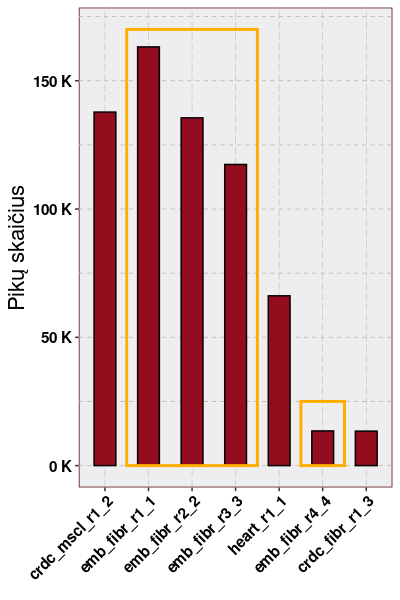

```r
# Creating Sample Key table:
samples <- read.csv(file = paste0(INTERMEDIATE_FILES, "sample_key.csv"))

# Importing BigBed format files:
bbfiles <- list.files(path = paste0(INPUTS, "BigBed/"), "*bb")
grl <- GRangesList()

# Declaring what chromosomes are analyzed:
chr_abr <- c(paste0("chr", 1:19), "chrX", "chrY")

# Creating GRanges objects and extracting certain chromosomes:
for (i in 1:length(bbfiles)) {
    grl[[i]] <- import(paste0(INPUTS, "BigBed/", bbfiles[i])) %>%
                       filter(seqnames %in% chr_abr)
    names(grl)[i] <- samples$Graph_names[samples$Filename == bbfiles[i]]
}

# Creating peak dataframe that keeps data about total peak counts in
# each sample:
peaks <- lapply(grl, length) %>%
            as.data.table()  %>%
            melt() %>%
            as.data.frame()  %>%
            setnames(., c("Experiment", "Peak_count"))

# Picking random dark red color:
col_fill <- randomColor(1, hue = "red", luminosity = "dark")

# Creating a barplot that visualizes peak differences in samples:
plot1 <- ggplot(peaks, aes(x = Experiment, y = Peak_count)) +
            geom_bar(stat = "identity", position = "dodge", width = 0.5,
                     color = "black", fill = "#930d1f") +
            labs(x = "", y = "Pikų skaičius", size = 5) +
            ylim(0, 200000) +
            scale_y_continuous(labels = label_number(suffix = " K",
                               scale = 1e-3)) +
            theme(panel.background = element_rect(fill = "#eeeef1",
                                                  colour = "#4c0001"),
                  panel.grid.major.y = element_line(colour = "#cab5b5",
                                           size = 0.3, linetype = "dashed"),
                  panel.grid.minor.y = element_line(colour = "#cab5b5",
                                           size = 0.3, linetype = "dashed"),
                  panel.grid.major.x = element_line(colour = "#cab5b5",
                                           size = 0.2, linetype = "longdash"),
                  panel.grid.minor.x = element_line(colour = "#cab5b5",
                                           size = 0.2, linetype = "longdash"),
                  axis.text.x = element_text(angle = 45, hjust = 1, vjust = 1,
                                   size = 11, face = "bold", color = "black"),
                  axis.text.y = element_text(size = 11, face = "bold",
                                   color = "black"),
                  axis.title.x = element_text(size = 2),
                  axis.title.y = element_text(size = 16),
                  plot.title = element_text(hjust = 0.5, face = "bold")) +
                  annotate("rect", xmin = 1.5, xmax = 4.5, ymin = -1, size = 1,
                           ymax = 170000, alpha = 0, color = "#ffae00") +
                  annotate("rect", xmin = 5.5, xmax = 6.5, ymin = -1, size = 1,
                           ymax = 25000, alpha = 0, color = "#ffae00")

plot1
```

According to the barchart, the greatest number of peaks was determined in the cells from *`emb_fibr_r1_1, 163190`* sample. The smallest number of peaks was observed in the dataset that was retrieved from *`crdc_fibr_r1_3, 13440`* sample.

### Peak counts by chromosome

The barcharts below show how peak counts are distributed within different chromosomes. Each bar represents separate sample.

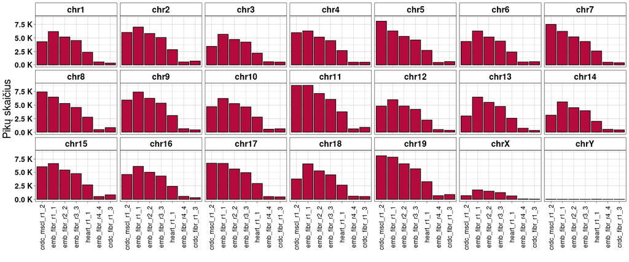

```r
# Disabling scientific notation:
options(scipen = 100)

# Creating a dataframe that stores data about peak counts in each
# chromosome for different samples:
peak_counts <- data.frame(matrix(ncol = 3, nrow = 0)) %>%
                    setNames(., c("Name", "Chromosome", "Peak_count"))

# Defining chromosome lenghts (Mbp) based on MGI data:
chr_mbp <- c(195, 182, 160, 157, 152, 150, 145, 130, 124, 131,
             122, 120, 121, 125, 104, 98, 95, 91, 61, 169, 91)

# Calculating chromosome lenghts in bp:
chr_bp <- chr_mbp * 1000000

# Declaring a function that calculates how many peaks are in each chromosome:
count_peaks <- function(name, objects) {
    for (chr in 1:21) {
            peaks <- objects[[name]] %>%
                    filter(seqnames == chr_abr[chr]) %>%
                    length() / chr_bp[chr] * 100000000
            peak_counts[nrow(peak_counts) + 1,] = c(name, chr_abr[chr], peaks)
        }
        return(peak_counts)
    }

peak_counts <- lapply(names(grl), count_peaks, objects = grl) %>% bind_rows()

# write.csv(peak_counts, paste0(INTERMEDIATE_FILES, "peaks_by_chr_nnorm.csv"))
# write.csv(peak_counts, paste0(INTERMEDIATE_FILES, "peaks_by_chr_norm.csv"))

# Calling factor() function in order to maintain certain Chromosome and Name
# order:
cas <- unique(peak_counts$Chromosome)
peak_counts$Chromosome <- factor(peak_counts$Chromosome, levels = c(cas))
peak_counts$Name <- factor(peak_counts$Name, levels = unique(peak_counts$Name))

# Note: it is essential to add 'as.numeric'. Otherwise, Peak_count is
# considered as 'string' type - column values are represented in
# lexicographic order which leads to wrong visualization.

# Creating barplots that visualize peak differences between different
# chromosomes:
plot2 <- ggplot(peak_counts, aes(x = Name, y = as.numeric(Peak_count))) +
            geom_bar(stat = "identity", color = "black", fill = col_fill) +
            facet_wrap(~ Chromosome, ncol = 7) +
            ylab("Pikų skaičius") +
            xlab("") +
            scale_y_continuous(labels = label_number(suffix = " K",
                               scale = 1e-3)) +
            theme_linedraw() +
            theme(axis.text.x = element_text(angle = 90, size = 12,
                  vjust = 0.5),
                  legend.position = "none",
                  axis.text.y = element_text(size = 14, face = "bold"),
                  axis.title.x = element_text(size = 14, colour = "black"),
                  axis.title.y = element_text(size = 20, colour = "black"),
                  strip.background = element_rect(fill = "white"),
                  strip.text = element_text(colour = "black", face = "bold",
                                            size = 16))

plot2
```

### Peak overlaps between samples

The heatmap below helps to indicate sample similarity be determining the percentage of the overlaping peak regions.

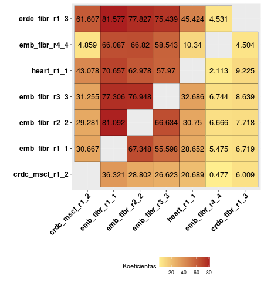

```r
# Creating a matrix that is filled with 'NA':
coef_matrix <- matrix(nrow = length(grl), ncol = length(grl))

# Declaring a function that calculates modified Jaccard coefficient:
jaccard <- function(a, b) {
    len <- reduce(c(grl[[a]], grl[[a]])) %>% length()
    return((length(GenomicRanges::intersect(grl[[a]], grl[[b]])) / len) * 100)
}

# Calculating Jaccard coefficient for sample pair:
for (i in 1:length(grl)) {
    for (y in 1:length(grl)) {
        coef_matrix[i, y] = jaccard(i, y)
    }
}

# Setting colnames and rownames for the matrix:
colnames(coef_matrix) <- names(grl)
rownames(coef_matrix) <- names(grl)

coef_mat1 <- coef_matrix
coef_mat2 <- coef_matrix

# Passing Jaccard coefficients to matrix except for the diagonal - it
# contains 'NA':
coef_mat1[lower.tri(coef_mat1, diag = TRUE)] <- NA
coef_mat2[upper.tri(coef_mat2, diag = TRUE)] <- NA

# Binding two matrixes:
coef_mat_bind <- rbind(data.matrix(coef_mat1), data.matrix(coef_mat2))

# Translating matrix to dataframe using melt() function:
melt_coef_mat <- melt(coef_mat_bind, na.rm = TRUE)

# Creating a heatmap that shows similarity between samples:
plot3 <- ggplot(melt_coef_mat, aes(x = Var2, y = Var1, fill = value)) +
            geom_tile(color = "black") +
            geom_text(aes(label = round(value, digits = 3)), size = 4.5,
                          color = "#030101") +
            labs(x = "", y = "") +
            scale_fill_gradient(low = "#ffee8e", high = "#ab1f1f") +
            guides(fill = guide_colourbar(title = "Koeficientas",
                   face = "bold")) +
            theme(axis.text = element_text(size = 12, colour = "black",
                                           face = "bold"),
                  axis.text.x = element_text(angle = 45, hjust = 1, vjust = 1),
                  axis.title.x = element_text(size = 14, colour = "black"),
                  axis.title.y = element_text(size = 14, colour = "black"),
                  panel.grid.major = element_line(color = "#eeeeee"),
                  plot.title = element_text(hjust = 0.5, size = 16,
                                            face = "bold"),
                  legend.position = "bottom")

plot3
```

### Tbx5 motif determination using PWM matrix

The following step of analysis determines Tbx5 motif hit count in FASTA files that store sequences of the corresponding genomic positions using positional weight matrix (PWM) of Tbx5 transcription factor.

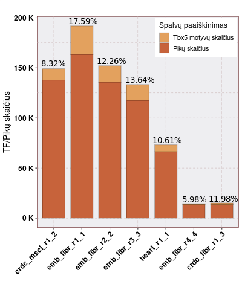

```r
# Calculating Tbx5 hits within fetched fasta files of peaks:
peak_sequences <- list.files(path = paste0(INPUTS, "FASTA/"), "*fasta")

hit_vec <- c()

# Creating an empty dataframe:
tbx5_hits <- data.frame(matrix(ncol = 3, nrow = 0)) %>%
                setNames(., c("Sample", "Peak_count", "Tbx5_hits"))

# Declaring a function that calculates Tbx5 motif hits in each sample:
find_motif_hits <- function(sequences) {
    for (i in 1:length(sequences)) {
        hits <- countPWM(as.matrix(mpwm), sequences[[i]], min.score = "75%")
        if (hits == 0) { next }
        else { hit_vec <- c(hit_vec, hits)}
    }
    return(sum(hit_vec))
}

# Declaring a function that calculates total peak count in each sample:
calculate_peaks <- function(filename) {
    name <- paste0(tools::file_path_sans_ext(filename), ".bb")
    file <- import(paste0(INPUTS, "BigBed/", name)) %>%
                    filter(seqnames %in% chr_abr)
    region_count <- length(file)
    return(region_count)
}

# Reading a file that stores information about Tbx5 motif counts and
# peak percentages:
motif_data <- read.csv(file = paste0(INTERMEDIATE_FILES, "tbx5_motif_data.csv"))

# Calling factor() function in order to maintain certain Sample order:
motif_data$Sample <- factor(motif_data$Sample, levels = motif_data$Sample)

# Subseting data to extract all columns except for 'X' column (column 1):
subset_df <- motif_data[, 2:5]

# 'Melting' the dataframe:
melted_df <- melt(subset_df)

# Creating a barplot that visualizes Tbx5 motif distribution within samples:
plot4 <- ggplot(data = melted_df, aes(x = Sample, y = value,
                                      fill = variable, label = value)) +
            geom_bar(stat = "identity", colour = "#35170450", size = 0.5,
                     width = 0.8) +
            scale_fill_manual(values = c("#e3a15e", "#c7633b"),
                              labels = c("Tbx5 motyvų skaičius",
                                         "Pikų skaičius")) +
            scale_y_continuous(labels = label_number(suffix = " K",
                                                     scale = 1e-3)) +
            guides(fill = guide_legend(title = "Spalvų paaiškinimas",
                                       size = 6)) +
            labs(title = "", x = "", y = "TF/Pikų skaičius") +
            theme(axis.text = element_text(size = 10, colour = "black"),
                  axis.text.x = element_text(angle = 45, hjust = 1, vjust = 1,
                                             size = 12, face = "bold"),
                  axis.text.y = element_text(size = 12, face = "bold"),
                  axis.title.x = element_text(size = 14, colour = "black"),
                  axis.title.y = element_text(size = 14, colour = "black"),
                  panel.grid.major = element_line(color = "#eeeeee"),
                  plot.title = element_text(hjust = 0.5, size = 16,
                                            face = "bold"),
                  panel.background = element_rect(fill = "#eeeef1",
                                                  colour = "#4c0001"),
                  panel.grid.major.y = element_line(colour = "#cab5b5",
                                            size = 0.3, linetype = "dashed"),
                  panel.grid.minor.y = element_line(colour = "#cab5b5",
                                            size = 0.3, linetype = "dashed"),
                  panel.grid.major.x = element_line(colour = "#cab5b5",
                                            linetype = "longdash", size = 0.2),
                  panel.grid.minor.x = element_line(colour = "#cab5b5",
                                            linetype = "longdash", size = 0.2),
                  legend.position = c(0.79, 0.9),
                  legend.title = element_text(size = 12),
                  legend.text = element_text(size = 11))

plot4
```

### *De novo* motif discovery

The bar chart below visualizes total identified motif count for each sample.

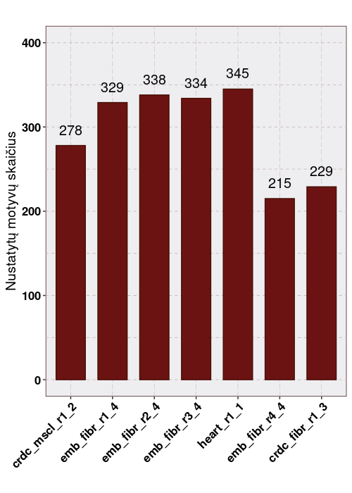

```r
# Reading a file that stores lists of motifs that were identified in
# each sample:
identified_motifs <- read.csv(file = paste0(INTERMEDIATE_FILES,
                              "identified_motifs.csv"))

# Getting rid of 'NA' values:
motif_counts <- data.frame(Motif_count = colSums(!is.na(identified_motifs)))

# Setting rownames to numbers:
rownames(motif_counts) <- NULL

# Making a new column with sample names:
motif_counts['Sample'] <- colnames(identified_motifs)

# Changing column order:
motif_counts <- motif_counts[, c(2, 1)]

# Calling factor() function in order to maintain certain Sample order:
motif_counts$Sample <- factor(motif_counts$Sample, levels = motif_counts$Sample)

# Creating a barplot that visualizes identified motif counts for each sample:
plot5 <- ggplot(motif_counts, aes(x = Sample, y = Motif_count)) +
            geom_bar(stat = "identity", fill = "#6b1313", width = .7,
                     color = "#4a1004") +
            labs(title = "", x = "", y = "Nustatytų motyvų skaičius") +
            ylim(0, 400) +
            geom_text(aes(label = Motif_count), color = "#030101", size = 5,
                          vjust = -1) +
            theme(axis.text = element_text(size = 10, colour = "black"),
                  axis.text.x = element_text(angle = 45, hjust = 1, size = 12,
                                             vjust = 1, face = "bold"),
                  axis.text.y = element_text(size = 12, face = "bold"),
                  axis.title.x = element_text(size = 14, colour = "black"),
                  axis.title.y = element_text(size = 14, colour = "black"),
                  panel.grid.major = element_line(color = "#eeeeee"),
                  plot.title = element_text(hjust = 0.5, size = 16,
                                            face = "bold"),
                  panel.background = element_rect(fill = "#eeeef1",
                                                  colour = "#3a1010"),
                  panel.grid.major.y = element_line(colour = "#cab5b5",
                                           size = 0.3, linetype = "dashed"),
                  panel.grid.minor.y = element_line(colour = "#cab5b5",
                                           size = 0.3, linetype = "dashed"),
                  panel.grid.major.x = element_line(colour = "#cab5b5",
                                           size = 0.2, linetype = "longdash"),
                  panel.grid.minor.x = element_line(colour = "#cab5b5",
                                           size = 0.2, linetype = "longdash"),
                  legend.position = c(0.777, 0.788))

plot5
```

### Conclusion

Summarizing the results of the analysis it can be determined that Tbx5 transcription factor motif hit counts notably vary between the samples where *Mus musculus* heart cells were affected with different treatments.

On the other hand, it must be taken into account that it is difficult to perform ChIP sequencing without making any mistakes and easily choosing proper parameters. Due to this reason possible ChIP-seq aberrations should be carefully considered.

**Click to see page metadata**

Computation Started: `2022-06-18 21:08:36`

Finished in `1.556 mins`

**Git Log**

No git history available for this page

**Packages**

| package | version | date |
| --- | --- | --- |
| backports | 1.4.1 | 2022-04-29 |
| genomation | 1.28.0 | 2022-05-06 |
| plyr | 1.8.7 | 2022-04-28 |
| lazyeval | 0.2.2 | 2022-04-28 |
| splines | 4.2.0 | 2022-04-28 |
| BiocParallel | 1.30.0 | 2022-04-30 |
| GenomeInfoDb | 1.32.1 | 2022-04-29 |
| ggplot2 | 3.3.5 | 2022-04-28 |
| gridBase | 0.4-7 | 2022-05-06 |
| digest | 0.6.29 | 2022-04-28 |
| foreach | 1.5.2 | 2022-04-28 |
| htmltools | 0.5.2 | 2022-04-28 |
| viridis | 0.6.2 | 2022-04-28 |
| fansi | 1.0.3 | 2022-04-28 |
| magrittr | 2.0.3 | 2022-04-28 |
| memoise | 2.0.1 | 2022-04-29 |
| BSgenome | 1.64.0 | 2022-05-06 |
| cluster | 2.1.3 | 2022-05-04 |
| tzdb | 0.3.0 | 2022-05-04 |
| Biostrings | 2.64.0 | 2022-04-29 |
| readr | 2.1.2 | 2022-05-04 |
| annotate | 1.74.0 | 2022-04-30 |
| matrixStats | 0.62.0 | 2022-05-05 |
| methods | 4.2.0 | 2022-04-28 |
| colorspace | 2.0-3 | 2022-04-28 |
| blob | 1.2.3 | 2022-04-29 |
| xfun | 0.30 | 2022-04-29 |
| dplyr | 1.0.9 | 2022-04-28 |
| crayon | 1.5.1 | 2022-04-28 |
| RCurl | 1.98-1.6 | 2022-04-29 |

[output cut: 119 more lines]

**System Information**

|  | systemInfo |
| --- | --- |
| version | R version 4.2.0 (2022-04-22) |
| platform | x86_64-pc-linux-gnu (64-bit) |
| locale | lt_LT.utf8 |
| OS | Linux Mint 20.1 |
| UI | X11 |

**Scikick Configuration**

```bash
cat scikick.yml
```

```
### Scikick Project Workflow Configuration File

# Directory where Scikick will store all standard notebook outputs
reportdir: report

# --- Content below here is best modified by using the Scikick CLI ---

# Notebook Execution Configuration (format summarized below)
# analysis:
#  first_notebook.Rmd:
#  second_notebook.Rmd:
#  - first_notebook.Rmd     # must execute before second_notebook.Rmd
#  - functions.R            # file is used by second_notebook.Rmd
#
# Each analysis item is executed to generate md and html files, E.g.:
# 1. <reportdir>/out_md/first_notebook.md
# 2. <reportdir>/out_html/first_notebook.html
analysis: !!omap
- samples.Rmd:
- peaks_MM.Rmd:
version_info:
  snakemake: 7.0.0
  ruamel.yaml: 0.17.21
  scikick: 0.2.0
```

**Functions**